# Math 611 HW1

Jeff Gould

8/30/2020

### 2

Consider the queue model discussed in class (i.e. a single server model). As in class, assume that the interarrival times, $T_i$ are iid as are the service times $V_i$. Assume further that each $T_i$ is exponentially distributed with rate $\lambda$ and each $V_i$ is exponentially distributed with rate $\mu$. Let $X(t)$ be the number of customers waiting in line at time $t$. Let $W_i$ be the waiting time of the $i$th individual. Assume that initially the queue is empty, so $X(0) = 0$ and $W_1 = 0$.

#### a) Determine $P(W_2 \ge c)$ for $c$ a positive number. (write down an integral and evaluate it, you won’t need a computer).

#### b) Write down an integral expression for $P(W_3 \ge c)$ (You don’t need to evaluate the integral, unless you want to. Your answer may be the sum of two integrals.)

#### c) Write a function WaitingTimes(n $\lambda$, $\mu$) that samples the waiting times of the first $n$ customers. Your function should return a vector of length $n$ with the sampled waiting time. Show the output of your function for $n=10, \lambda=1, \mu=1$.

```r
waitingTimes <- function(n, lambda, mu){

  ### First, create a vector of length n for T_i's, the time between cutomer arrivals
  T_i <- rexp(n, rate = lambda)
  ### Turn T_i into a vector of arrival times, A
  A <- cumsum(T_i)

  ### Now create vector of service time for each person
  V <- rexp(n, rate = mu)

  ### Initialize W with W_1 = 0
  W <- c(0)

  ### The departure time of the first customer is simply their service time + arrival time
  D <- V[1] + A[1]

  for (i in 2:n) {
    ## The wait time of the ith customer is max(0, D_(i-1) - A_i)
    W[i] <- max(0, D[i - 1] - A[i])

    ## The departure time of the ith customer is their arrival time + their wait time + their service time
    D[i] <- A[i] + W[i] + V[i]
  }

  return(W)

}

set.seed(123)
waitingTimes(10,1,1)
```

```
##  [1] 0.0000000 0.4282198 0.0000000 0.2494363 0.5703431 0.4421259 0.9776848
##  [8] 2.3956215 0.1481455 0.7099269
```

#### d) Write a function plotQueue(t, $\lambda$, $\mu$) that simulates (in other words samples) the queue and plots $X(t)$ up to a time $t$. Show a single simulation for $t=20$, $\lambda=1$, $\mu=1$.

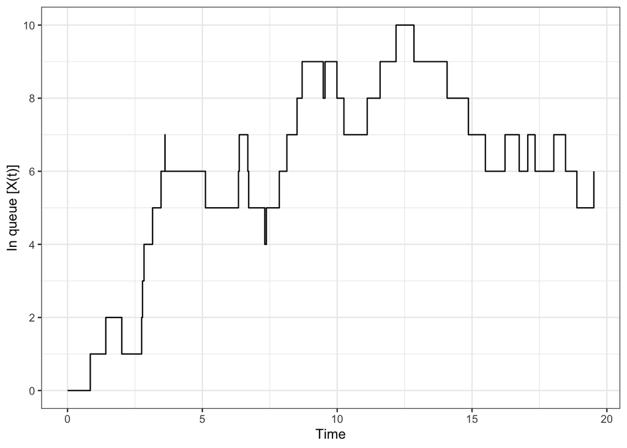

```r
set.seed(123)
plotQueue <- function(t, lambda, mu){

  T_i <- rexp(1, lambda)

  while (sum(T_i) <= t) {
    T_i <- c(T_i, rexp(1, lambda))
  }

  A <- cumsum(T_i)
  n <- length(T_i)
  ### Now create vector of service time for each person
  V <- rexp(n, rate = mu)

  ### Initialize W with W_1 = 0
  W <- c(0)

  ### The departure time of the first customer is simply their service time + arrival time
  D <- V[1] + A[1]

  for (i in 2:n) {
    ## The wait time of the ith customer is max(0, D_(i-1) - A_i)
    W[i] <- max(0, D[i - 1] - A[i])

    ## The departure time of the ith customer is their arrival time + their wait time + their service time
    D[i] <- A[i] + W[i] + V[i]
  }

  steps <- sort(c(0,A,D))
  steps <- steps[steps <= t]

  inqueue <- function(Arrival, Departure, time){
    return(
      if(Arrival <= time & time < Departure){1}else{0}
    )

  }

  Xt <- sum(mapply(inqueue, A,D, time = steps[1]))
  for (j in 2:length(steps)) {
    Xt[j] = sum(mapply(inqueue, A,D, time = steps[j]))
  }

  X <- data.frame(steps, Xt)

  ggplot(X, aes(x = steps, y = Xt)) +
    geom_step() +
    theme_bw() +
    labs(x = "Time", y = "In queue [X(t)]") +
    scale_y_continuous(breaks = seq(0,max(X$Xt) + 2, 2))

}

plotQueue(20,1,1)
```

#### e) Using a Monte Carlo approach, estimate $P(W_2 \ge 1)$. Assume $\lambda = 1$, $\mu = 1$. Compare your estimate to the exact answer you derived in part (a). Repeat for $P(W_{100} \ge 1)$, except in this case you won’t have the exact answer.

Let $N = 100000$

```r
set.seed(123)
N <- 100000
#cl <- parallel::detectCores()
cl <- parallel::makeCluster(parallel::detectCores() - 1)

WaitTimes <- t(parallel::parSapply(cl, X = rep(2, N), FUN = waitingTimes, lambda = 1, mu = 1))

P <- mean(WaitTimes[,2] >=1)
#parallel::stopCluster(cl)
```

Runing the above, we find that the probabilty the second customer has to wait in line more than $1$ time unit is 0.18419

We follow the same process for $W_{100}$, simply expand `n` in `waitingTimes` to 100 instead of 2

```r
set.seed(123)
N <- 100000
#cl <- parallel::detectCores()
#cl <- parallel::makeCluster(parallel::detectCores() - 1)

WaitTimes <- t(parallel::parSapply(cl, X = rep(100, N), FUN = waitingTimes, lambda = 1, mu = 1))

P <- mean(WaitTimes[,100] >=1)
parallel::stopCluster(cl)
```

Runing the above, we find that the probabilty the $100^{th}$ customer has to wait in line more than $1$ time unit is 0.88769